# 2022/6/29 進捗報告

## 今週の進捗

- AOD-COTの相関係数の空間分布とAOD-CERの相関係数の空間分布の比較
- 時系列の解析
  - 7,8月平均で時系列の解析
  - 2,5,8,11月を季節の代表として対象領域の平均をとって時系列を比較(途中)
- 解析方法の検証
  - アフリカ西岸地域に対して2005年の1年間を通してTwomey Effectが出ているのか調べる(途中)
- 風、相対湿度のデータをera5から取得し、その値に基づいてエアロゾルと雲パラメータを比較(途中)

## AOD-COTの相関係数の空間分布とAOD-CERの相関係数の空間分布の比較

COTとCWPの定義から近似的に、

$$ COT = \frac{3}{2\rho}\frac{CWP}{r_{e}} $$

であるから、AOD-CERが正の相関を持つならば、AOD-COTは負の相関を持つはず。

- 全体的にAOD-COTは負の相関を示す
- COT, CER共にCWPが25未満の場合にはAODとの相関が小さい(特にCOT) → `各セルに存在するデータ数の見直しや、AOD, COTの分布を見ておかしな箇所がないか確認する`

### CWP < 25

[figure not shown]

### 25 < CWP < 50

[figure not shown]

### 50 < CWP < 75

[figure not shown]

### 75 < CWP < 100

[figure not shown]

### 100 < CWP

[figure not shown]

## CERの空間分布

### CWP < 25

[figure not shown]

### 25 < CWP < 50

[figure not shown]

### 50 < CWP < 75

[figure not shown]

### 75 < CWP < 100

[figure not shown]

### 100 < CWP

[figure not shown]

## 時系列によるAOD, CERの変動(7, 8月)

### 手法

- 対象領域全体(30-42°N, 115-125°E)の7,8月のAODとCERを年毎に平均

### 結果

- AOD, CER共に年々小さくなっている
- 時系列の変動もAODの変動に対してCERが非常に似た変動を示す

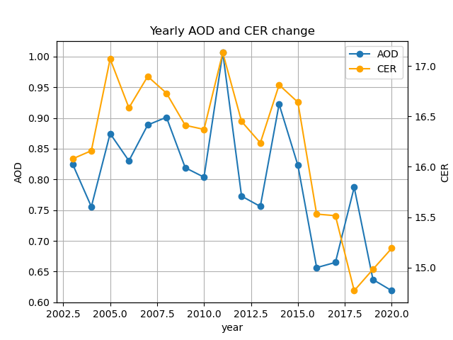

# 今後の取り組み

### [実行中]時系列によるAOD, CERの変動(2, 5, 8, 11月)

- 2, 5, 8, 11月を冬、春、夏、秋の代表月として時系列の変動をみる（7月の梅雨の影響を避けるために夏の代表月を8月とし、そこから3ヶ月ごとにそれぞれの季節の代表月を決めた）
- 領域全体だけでなく、北京、上海周辺など、地域を限定した時系列の変動もみる
- AOD, CERに加え、COT, CFの変動もみる

### [実行中]解析方法の検証

- アフリカ西岸地域に対して2005年の1年間を通してTwomey Effectが出ているのか調べる

### [実行中]風、相対湿度のデータをera5から取得し、その値に基づいてエアロゾルと雲パラメータを比較

- BLH以下の風、相対湿度データをera5から抽出する
- 風向き、風速、相対湿度の条件で場合分けをして、各パターンごとにAODと雲パラメータの間に特徴が出ているか調べる

### MERRA2からエアロゾルの種類ごとのデータを取得してパターンを調べる